# DVR_Project2

*Group Members: Aura Maria Salazar, Adriana Murga*

Our data was taken from https://support.spatialkey.com/spatialkey-sample-csv-data/ The file we chose from this website is called TechCrunch Continental USA and contains the listing 1,460 company funding records reported by TechCrunch.

## The Steps

### Step 1

The first step to produce our project was to look for the data. Our data was taken from https://support.spatialkey.com/spatialkey-sample-csv-data/. The file we chose from this website is called TechCrunch Continental USA and contains the listing 1,460 company funding records reported by TechCrunch.

### Step 2

Once we chose our data we begun to set up the data to create the oracle database. We modified the R_ETL.R. file to load our csv file into our oracle account. This file can be found under the folder named 02 Data Wrangling by the name ‘Set up.R’

Here’s a summary of what our data looks like. You need to run the code in this file in order to proceed to get the data wrnaglings and visualization.

```r
source("../01 Data/Summary_Data.R", echo = TRUE)
```

```
##
## > require("jsonlite")
```

```
##
## > require("RCurl")
```

```
##
## > df1 <- data.frame(fromJSON(getURL(URLencode("129.152.144.84:5001/rest/native/?query=\"select * from TechCrunchcontinentalUSA\""),
## +     httpheader  .... [TRUNCATED]
##
## > summary(df1)
##            PERMALINK                   COMPANY         CATEGORY
##  facebook       :   7   Facebook           :   7   web     :1208
##  actionengine   :   5   Action Engine      :   5   software: 102
##  answers        :   5   Answers Corporation:   5   mobile  :  48
##  brightcove     :   5   Brightcove         :   5   hardware:  39
##  glammedia      :   5   Glam Media         :   5   null    :  24
##  jingle-networks:   5   Jingle Networks    :   5   other   :  16
##  (Other)        :1428   (Other)            :1428   (Other) :  23
##             CITY         STATE        FUNDEDDATE   RAISEDCURRENCY
##  San Francisco:228   CA     :873   1-Jan-08:  54   CAD:   1
##  New York     : 93   NY     :125   1-Oct-07:  54   EUR:   1
##  Mountain View: 89   MA     :107   1-May-07:  49   USD:1458
##  Palo Alto    : 78   WA     : 97   1-Jan-07:  47
##  Seattle      : 75   CO     : 33   1-Sep-07:  47
##  San Mateo    : 70   TX     : 25   1-Jun-07:  44
##  (Other)      :827   (Other):200   (Other) :1165
##      ROUND        NUMEMPS      RAISEDAMT
##  a      :582   null   :893   Min.   :     6000
##  b      :371   10     : 30   1st Qu.:  2000000
##  c      :141   0      : 28   Median :  5500000
##  angel  :135   6      : 25   Mean   : 10131488
##  seed   :128   20     : 24   3rd Qu.: 11025000
##  d      : 47   3      : 22   Max.   :300000000
##  (Other): 56   (Other):438
```

If like us you were wondering what the data in column ‘round’ stands for, here’s an explanation: * Pre-funding: You build a prototype of your product. * Seed Round: The funding necessary to launch your product. * A Round: The funding necessary to get product traction. * B Round: The funding necessary to scale your product

### Step 3

Once we had our data in place we continued by playing around with it. In the folder 02 Data Wrangling there’s a script called First_RE.R where we began playing with our data using grep.

```r
source("../02 Data Wrangling/First_RE.R", echo=TRUE)
```

```
##
## > require(tidyr)
```

```
##
## > require(dplyr)
```

```
##
## > require(ggplot2)
```

```
##
## > tmp <- df1
##
## > test <- grep("TX", tmp$STATE, perl = TRUE, value = FALSE) %>%
## +     tmp[., c("COMPANY", "CITY", "STATE", "CATEGORY", "RAISEDAMT")] %>%
## +     tbl_d .... [TRUNCATED]
##
## > View(test)
##
## > test2 <- grep("^[sS]", tmp$COMPANY, perl = TRUE, value = FALSE) %>%
## +     tmp[., c("COMPANY", "CITY", "STATE", "CATEGORY")] %>% tbl_df
##
## > View(test2)
```

### Step 4

Here’s our first data wrangling.Here we took our data, grouped it by state, counted the number of distinct companies (some companies did more than one fund raise) per state and displayed it in a view arranged in descending order.Some interesting things we found from our data was that the state with the most companies raising money were California with a total of 533 companies follower by New York with 83. There’s a drastic difference between the two. Despite that we somewhat expected that California would be #1 followed by New York, we were very surprised to see that the difference between California and the rest of the companies ranges from 450-532, which is a very big difference.

```r
source("../02 Data Wrangling/DataWrangling1.R", echo=TRUE)
```

```
##
## > tmp <- df1
##
## > tmp %>% group_by(STATE) %>% summarise(n = n_distinct(COMPANY)) %>%
## +     arrange(desc(n)) %>% View
```

### Step 5

Here’s our second data wrangling. In this one we used group_by(). For this data wrangling we decided to arrange the data by category and compare how much money each category raised. The category that raised the most money was hardware, which did not surprise us becuase in order to use technology you need to have a product to use it through. However, what did surprise us was that cleantech came in number three just below biotech. It was great to see that so much money is being invested in technologies that will aid hummanity both in health needs and in perserving the planet. We would have excpected that software or/and mobile would come in on top after hardware but we were pleasantly surprised to see that biotech and cleantech were on top.

```r
source("../02 Data Wrangling/DataWrangling2.R", echo=FALSE)
View(dw2)
```

```r
source("../03 Visualizations/DW2.R", echo=TRUE)
```

```
##
## > ggplot(data = dw2, mapping = aes(x = CATEGORY, y = avg,
## +     color = CATEGORY, fill = CATEGORY)) + geom_bar(position = "dodge",
## +     stat = "ide ..." ... [TRUNCATED]
```

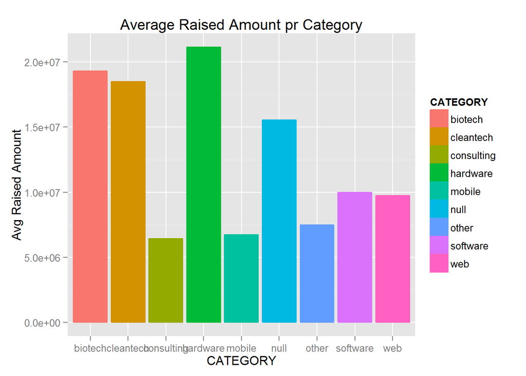

### Step 6

Here’s our third data wrangling. In this one instead of using the amount of funding that each category raised we wanted to see how many companies actually fell into those categories. We were very surprised to see that despite the fact that hardware, biotech and cleantech companies were the ones that got the most funding, the number of companies founded that actually worked in that category were very small. We can see that the category of Web was the one that had the most companies by a big difference and it is follwed by software. Those categories did not raise nearly as much as hardware, biotech and cleantech and yet entrepreneurs decide that they want to go into software or Web(especially web.)

```r
source("../02 Data Wrangling/DataWrangling3(1).R", echo=TRUE)
```

```
##
## > dw4 <- df1 %>% select(CATEGORY, COMPANY) %>% group_by(CATEGORY) %>%
## +     summarise(y = n_distinct(COMPANY))
```

```r
source("../03 Visualizations/DW3(1).R", echo=TRUE)
```

```
##
## > ggplot(data = dw4, mapping = aes(x = CATEGORY, y = y,
## +     color = CATEGORY, fill = CATEGORY)) + geom_bar(position = "dodge",
## +     stat = "ident ..." ... [TRUNCATED]
```

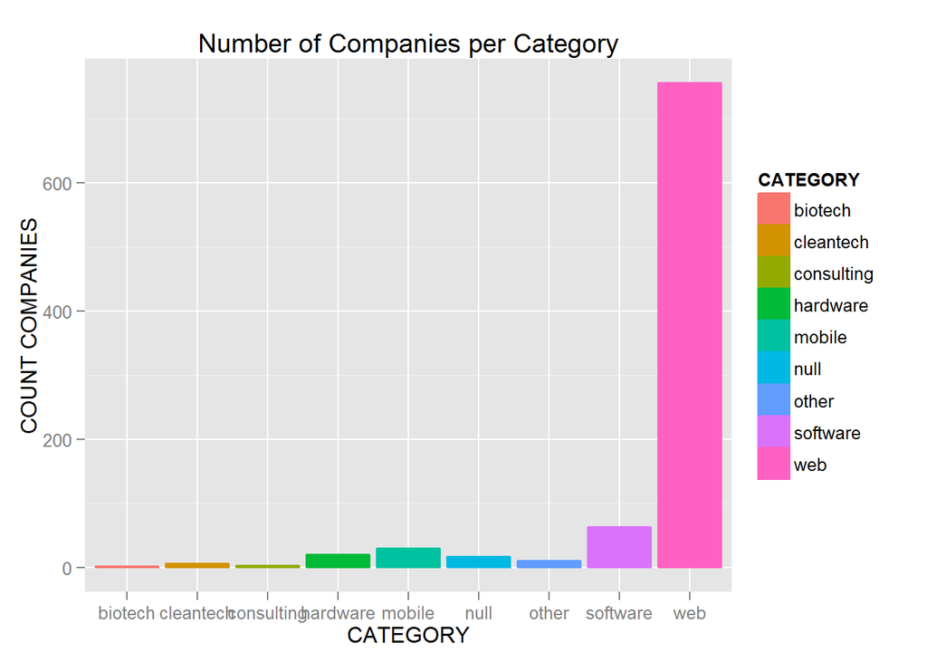

### Step 7

For our fourth data wrangling, we decided to look at the average raised amount per state. Surprisingly the highest average raised amount was not from California, which was the state with the most companies.

```r
source("../02 Data Wrangling/DataWrangling4.R", echo=TRUE)
```

```
##
## > dw4 <- df1 %>% select(STATE, RAISEDAMT) %>% group_by(STATE) %>%
## +     summarise(avg_amt = mean(RAISEDAMT))
```

```r
source("../03 Visualizations/DW4.R", echo=TRUE)
```

```
##
## > ggplot(data = dw4, mapping = aes(x = STATE, y = avg_amt)) +
## +     geom_bar(position = "dodge", stat = "identity") + labs(title = "Average Raised Am ..." ... [TRUNCATED]
```

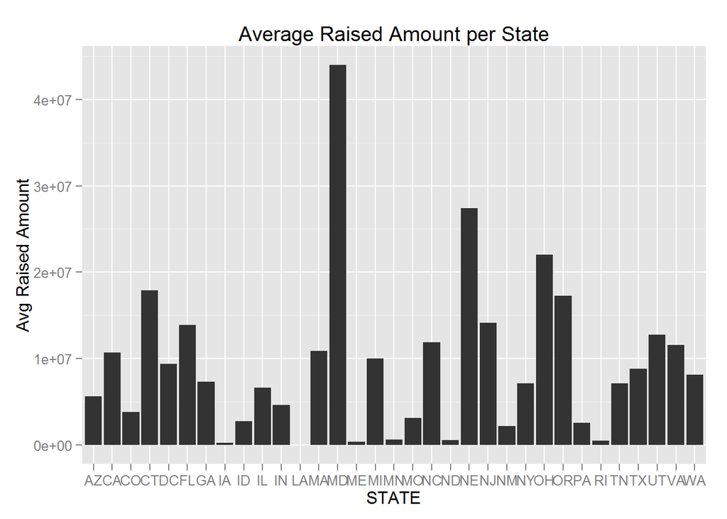